# R Notebook

```r
library(MVN)
mvn(data_AESTHEMOS)
```

| Test | Statistic | p value | Result |
| --- | --- | --- | --- |
| Mardia Skewness | 36777.1156876231 | 0 | NO |
| Mardia Kurtosis | 89.9472903282203 | 0 | NO |
| MVN | NA | NA | NO |

|  | Test | Variable | Statistic | p value | Normality |
| --- | --- | --- | --- | --- | --- |
| 1 | Shapiro-Wilk | beautiful | 0.8670 | <0.001 | NO |
| 2 | Shapiro-Wilk | challenge | 0.7513 | <0.001 | NO |
| 3 | Shapiro-Wilk | delight | 0.8216 | <0.001 | NO |
| 4 | Shapiro-Wilk | calm | 0.8001 | <0.001 | NO |
| 5 | Shapiro-Wilk | curious | 0.8690 | <0.001 | NO |
| 6 | Shapiro-Wilk | liked | 0.8865 | <0.001 | NO |
| 7 | Shapiro-Wilk | fascinated | 0.8341 | <0.001 | NO |
| 8 | Shapiro-Wilk | wonderful | 0.7959 | <0.001 | NO |
| 9 | Shapiro-Wilk | invigorated | 0.7918 | <0.001 | NO |
| 10 | Shapiro-Wilk | engaged | 0.8822 | <0.001 | NO |

[output cut: 32 more lines]

|  | n | Mean | Std.Dev | Median | Min | Max | 25th | 75th | Skew | Kurtosis |
| --- | --- | --- | --- | --- | --- | --- | --- | --- | --- | --- |
| beautiful | 703 | 2.529161 | 1.3676941 | 2 | 1 | 5 | 1 | 4 | 0.37431848 | -1.15774036 |
| challenge | 703 | 1.833570 | 1.1065254 | 1 | 1 | 5 | 1 | 2 | 1.23828085 | 0.62913362 |
| delight | 703 | 2.248933 | 1.3436761 | 2 | 1 | 5 | 1 | 3 | 0.67409448 | -0.85111303 |
| calm | 703 | 2.152205 | 1.3272908 | 2 | 1 | 5 | 1 | 3 | 0.81871592 | -0.63071582 |
| curious | 703 | 2.341394 | 1.2230371 | 2 | 1 | 5 | 1 | 3 | 0.49962727 | -0.84693027 |
| liked | 703 | 2.864865 | 1.4031721 | 3 | 1 | 5 | 2 | 4 | 0.06439734 | -1.29923617 |
| fascinated | 703 | 2.223329 | 1.2765346 | 2 | 1 | 5 | 1 | 3 | 0.68570708 | -0.73126574 |
| wonderful | 703 | 2.153627 | 1.3372849 | 2 | 1 | 5 | 1 | 3 | 0.77851103 | -0.74159778 |
| invigorated | 703 | 2.022760 | 1.2146048 | 2 | 1 | 5 | 1 | 3 | 0.87584120 | -0.40633638 |
| engaged | 703 | 2.470839 | 1.2569761 | 2 | 1 | 5 | 1 | 3 | 0.39030057 | -0.91398564 |

[output cut: 32 more lines]

```
NA
```

CFA with original AESTHEMOS Factors

```r
CFA_AESTHEMOS_orth.fit<-lavaan::cfa(CFA_AESTHEMOS,
                         data=data,

                      rotation='varimax',
                        orthogonal=TRUE,
                         estimator="WLSMV",
                         std.lv=TRUE)
```

```
lavaan WARNING: number of observations (703) too small to compute Gamma
lavaan WARNING:
    Could not compute standard errors! The information matrix could
    not be inverted. This may be a symptom that the model is not
    identified.lavaan WARNING: could not invert information matrix needed for robust test statistic
```

```r
fit_orth<-as.data.frame(fitmeasures(CFA_AESTHEMOS_orth.fit))


CFA_AESTHEMOS_obl.fit<-lavaan::cfa(CFA_AESTHEMOS,
                         data=data,

                     #  rotation='varimax',
                      #  orthogonal=TRUE,
                         estimator="WLSMV",
                         std.lv=TRUE)
```

```
lavaan WARNING: number of observations (703) too small to compute Gamma
```

```r
fit_obl<-as.data.frame(fitmeasures(CFA_AESTHEMOS_obl.fit))


# saving fitindices to dataframe

AEST_fitmeasures<-data.frame(
  "fitindices"=c("chi square",
                 "df (chi square)",
                 "p (chi square)",
                 "cfi",
                 "tli",
                 "rmsea",
                 "agfi" ),
  "orthogonal"=c(fit_orth["chisq",], fit_orth["df",], fit_orth["pvalue",], fit_orth["cfi",], fit_orth["tli",], fit_orth["rmsea",], fit_orth["agfi",]),

  "oblimin"= c(fit_obl["chisq",], fit_obl["df",], fit_obl["pvalue",], fit_obl["cfi",], fit_obl["tli",], fit_obl["rmsea",], fit_obl["agfi",]))

# reduce to only 2 decimal places so it looks less chaotic
is.num <- sapply(AEST_fitmeasures, is.numeric)
AEST_fitmeasures[is.num] <- lapply(AEST_fitmeasures[is.num], round, 2)
```

```r
print(AEST_fitmeasures)
```

| fitindices | orthogonal | oblimin |
| --- | --- | --- |
| chi square | 42043.24 | 7481.31 |
| df (chi square) | 819.00 | 798.00 |
| p (chi square) | 0.00 | 0.00 |
| cfi | 0.24 | 0.88 |
| tli | 0.20 | 0.87 |
| rmsea | 0.27 | 0.11 |
| agfi | 0.34 | 0.88 |

```r
NA
```

Fit

## STEP 1: determine the number of factors

```
Parallel analysis suggests that the number of factors =  7  and the number of components =  NA
```

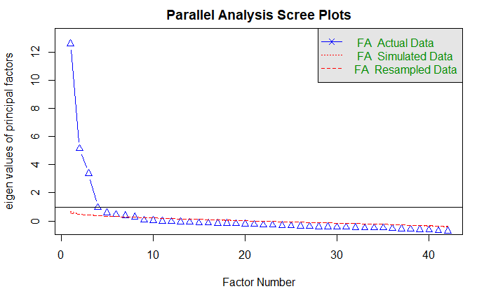

```r
fa.parallel(data_AESTHEMOS,  fm="wls", fa="fa")
```

### –> parallelanalysis and screeplot indicate 7 factors, which also has a the best fit when compared to other solutions

## STEP 2: Factor analysis with 7 factors (as suggested by previous parallel analysis), varimax rotation is applied, weighted least squares (WLS) is used to estimate the factors

### path diagram for the first EFA

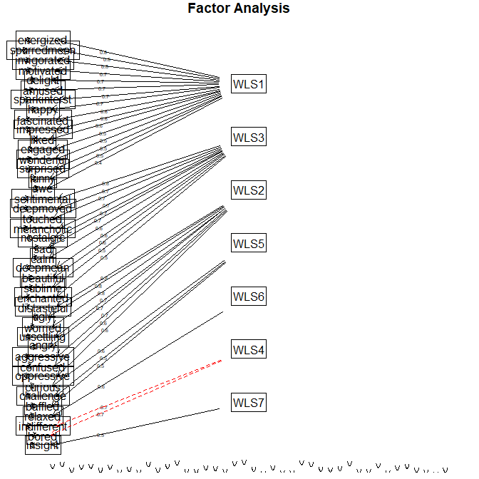

```r
#library(ggplot2)

#ggplot(EFA_results_long, aes(name,abs(loadings),fill=loadings))+
 #  facet_wrap(~factor, nrow=1)+
  # geom_bar(stat = "identity")+
  # coord_flip()+
  #scale_fill_gradient2(name="Factorloadings",high="turquoise4",mid="paleturquoise",low="salmon",    midpoint = 0, guide=F)+
  #ylab("Loading strength")+
  #xlab("Item name")+
 #theme_bw(base_size = 28)
```

The seven factor solution revealed some cross-loadings of items on several factors. Items that showed loadings on several factors with a difference of less than .20 were removed. Another EFA was carried out with the remaining items.

## to make the next step a bit simpler the retained items are saved into a new data frame

```r
EFA_reduced<-tibble(data$energized,
                    data$spurredmeon,
                    data$invigorated,
                    data$motivated,
                    data$delight,
                    data$happy,
                    data$amused,
                    data$funny,

                    data$sentimental,
                    data$deepmoved,
                    data$touched,
                    data$nostalgic,
                    data$melancholic,
                    data$sad,
                    data$deepmean,

                    data$distasteful,
                    data$ugly,
                    data$worried,
                    data$unsettling,
                    data$angry,
                    data$aggressive,
                    data$confused,
                    data$oppressive,

                    data$bored,
                    data$indifferent)

names(EFA_reduced)<-c("energized",
                    "spurredmeon",
                    "invigorated",
                    "motivated",
                    "delight",
                    "happy",
                    "amused",
                    "funny",

                    "sentimental",
                    "deepmoved",
                    "touched",
                    "nostalgic",
                    "melancholic",
                    "sad",
                    "deepmean",

                    "distasteful",
                    "ugly",
                    "worried",
                    "unsettling",
                    "angry",
                    "aggressive",
                    "confused",
                    "oppressive",
                    "bored",
                    "indifferent"
                    )


 EFA_ordered<- as.data.frame(lapply(EFA_reduced[
   ,c("energized",
      "spurredmeon",
      "invigorated",
      "motivated",
      "delight",
      "happy",
      "amused",
      "funny",

      "sentimental",
      "deepmoved",
      "touched",
      "nostalgic",
      "melancholic",
      "sad",
      "deepmean",

      "distasteful",
      "ugly",
      "worried",
      "unsettling",
      "angry",
      "aggressive",
      "confused",
      "oppressive",

      "bored",
      "indifferent"
                  )],
         ordered))
```

### second parallel analysis to determine the number of factors in the reduced data set

```
Parallel analysis suggests that the number of factors =  5  and the number of components =  NA
```

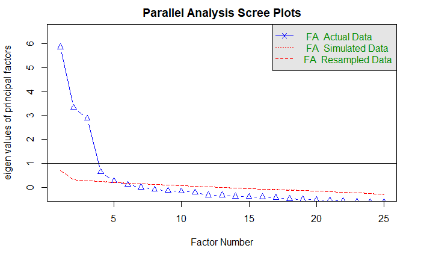

```r
fa.parallel(EFA_reduced,  fm="wls", fa="fa")
```

### A second factor analysis was carried out.

```r
second_EFA<-psych::fa(EFA_reduced, nfactors = 4, rotate='varimax',fm="wls", fa="fa")

print(second_EFA, sort=TRUE, digits = 2)
```

```
Factor Analysis using method =  wls
Call: psych::fa(r = EFA_reduced, nfactors = 4, rotate = "varimax",
    fm = "wls", fa = "fa")
Standardized loadings (pattern matrix) based upon correlation matrix
```

|  | item | WLS2 | WLS1 | WLS3 | WLS4 | h2 | u2 | com |
| --- | --- | --- | --- | --- | --- | --- | --- | --- |
| worried | 18 | 0.82 | -0.08 | 0.01 | -0.15 | 0.7089032 | 0.2910968 | 1.087588 |
| unsettling | 19 | 0.79 | -0.07 | -0.07 | -0.06 | 0.6400662 | 0.3599338 | 1.045076 |
| distasteful | 16 | 0.75 | -0.08 | -0.05 | 0.23 | 0.6262855 | 0.3737145 | 1.213225 |
| ugly | 17 | 0.73 | -0.12 | -0.12 | 0.21 | 0.6124487 | 0.3875513 | 1.280015 |
| angry | 20 | 0.70 | 0.01 | -0.01 | 0.06 | 0.4950553 | 0.5049447 | 1.015821 |
| aggressive | 21 | 0.69 | 0.09 | -0.02 | -0.05 | 0.4841073 | 0.5158927 | 1.045014 |
| oppressive | 23 | 0.64 | -0.05 | -0.09 | 0.04 | 0.4257198 | 0.5742802 | 1.061463 |
| confused | 22 | 0.59 | -0.10 | -0.02 | 0.07 | 0.3627344 | 0.6372656 | 1.087052 |
| energized | 1 | 0.03 | 0.83 | 0.02 | -0.18 | 0.7199473 | 0.2800527 | 1.095836 |
| spurredmeon | 2 | 0.10 | 0.76 | 0.00 | -0.11 | 0.5964305 | 0.4035695 | 1.079363 |

[output cut: 15 more lines]

```
                      WLS2 WLS1 WLS3 WLS4
SS loadings           4.68 4.29 3.84 1.30
Proportion Var        0.19 0.17 0.15 0.05
Cumulative Var        0.19 0.36 0.51 0.56
Proportion Explained  0.33 0.30 0.27 0.09
Cumulative Proportion 0.33 0.64 0.91 1.00

Mean item complexity =  1.2
Test of the hypothesis that 4 factors are sufficient.

The degrees of freedom for the null model are  300  and the objective function was  15.35 with Chi Square of  10636.92
The degrees of freedom for the model are 206  and the objective function was  2.27

The root mean square of the residuals (RMSR) is  0.04
The df corrected root mean square of the residuals is  0.05

The harmonic number of observations is  703 with the empirical chi square  671.29  with prob <  1.1e-50
The total number of observations was  703  with Likelihood Chi Square =  1566.67  with prob <  1.2e-207

Tucker Lewis Index of factoring reliability =  0.808
RMSEA index =  0.097  and the 90 % confidence intervals are  0.093 0.102
BIC =  216.27
Fit based upon off diagonal values = 0.98
Measures of factor score adequacy
                                                  WLS2 WLS1 WLS3 WLS4
Correlation of (regression) scores with factors   0.96 0.95 0.95 0.85
Multiple R square of scores with factors          0.92 0.91 0.91 0.72
Minimum correlation of possible factor scores     0.83 0.82 0.81 0.44
```

A CFA is carried out to confirm the EFA model with four factors.

```r
require(parameters)
if (require("psych") && require("lavaan"))


  #this model gets rejected
  model1<-'
  M1=~worried+ unsettling+distasteful + ugly
  M2=~energized + spurredmeon + motivated + invigorated
  M3=~deepmoved+touched+sentimental+melancholic
  M4=~bored+indifferent'

 model1.fit<-lavaan::cfa(model1,
                         data=EFA_reduced,
                         rotation='varimax',
                         orthogonal=TRUE,
                         estimator="WLSMV",
                         std.lv=TRUE)
```

```
lavaan WARNING:
    Could not compute standard errors! The information matrix could
    not be inverted. This may be a symptom that the model is not
    identified.lavaan WARNING: could not invert information matrix needed for robust test statistic
```

```r
#summary(model1.fit)
```

This model is rejected. As the measures for factor adequacy are comparatively low and there are only two items loading in that factor, another CFA was carried out with only the first major 3 factors.

```r
  # this model works
  model2<-'
  M1=~worried+ unsettling+distasteful + ugly
  M2=~energized + spurredmeon + motivated + invigorated
  M3=~deepmoved+touched+sentimental+melancholic '

 model2.fit<-lavaan::cfa(model2,
                         data=EFA_ordered,
                         rotation='varimax',
                         orthogonal=TRUE,
                         estimator="WLSMV",
                         std.lv=TRUE)

fitmeasures(model2.fit)
```

```
                         npar                          fmin                         chisq                            df                        pvalue
                       60.000                         0.654                       920.016                        54.000                         0.000
                 chisq.scaled                     df.scaled                 pvalue.scaled          chisq.scaling.factor                baseline.chisq
                      512.339                        54.000                         0.000                         1.897                     24076.566
                  baseline.df               baseline.pvalue         baseline.chisq.scaled            baseline.df.scaled        baseline.pvalue.scaled
                       66.000                         0.000                     12566.903                        66.000                         0.000
baseline.chisq.scaling.factor                           cfi                           tli                          nnfi                           rfi
                        1.921                         0.964                         0.956                         0.956                         0.953
                          nfi                          pnfi                           ifi                           rni                    cfi.scaled
                        0.962                         0.787                         0.964                         0.964                         0.963
                   tli.scaled                    cfi.robust                    tli.robust                   nnfi.scaled                   nnfi.robust
                        0.955                            NA                            NA                         0.955                            NA
                   rfi.scaled                    nfi.scaled                    ifi.scaled                    rni.scaled                    rni.robust
                        0.950                         0.959                         0.963                         0.963                            NA
                        rmsea                rmsea.ci.lower                rmsea.ci.upper                  rmsea.pvalue                  rmsea.scaled
                        0.151                         0.143                         0.160                         0.000                         0.110
        rmsea.ci.lower.scaled         rmsea.ci.upper.scaled           rmsea.pvalue.scaled                  rmsea.robust         rmsea.ci.lower.robust
                        0.101                         0.119                         0.000                            NA                            NA
        rmsea.ci.upper.robust           rmsea.pvalue.robust                           rmr                    rmr_nomean                          srmr
                           NA                            NA                         0.151                         0.163                         0.163
                 srmr_bentler           srmr_bentler_nomean                          crmr                   crmr_nomean                    srmr_mplus
                        0.151                         0.163                         0.163                         0.177                            NA
            srmr_mplus_nomean                         cn_05                         cn_01                           gfi                          agfi
                           NA                        56.055                        62.858                         0.975                         0.946
                         pgfi                           mfi
                        0.462                         0.540
```

```r
summary(model2.fit)
```

```
lavaan 0.6-7 ended normally after 22 iterations

  Estimator                                       DWLS
  Optimization method                           NLMINB
  Number of free parameters                         60

  Number of observations                           703

Model Test User Model:
                                              Standard      Robust
  Test Statistic                               920.016     512.339
  Degrees of freedom                                54          54
  P-value (Chi-square)                           0.000       0.000
  Scaling correction factor                                  1.897
  Shift parameter                                           27.367
       simple second-order correction

Parameter Estimates:

  Standard errors                           Robust.sem
  Information                                 Expected
  Information saturated (h1) model        Unstructured

Latent Variables:
                   Estimate  Std.Err  z-value  P(>|z|)
  M1 =~
    worried           0.870    0.019   45.117    0.000
    unsettling        0.891    0.017   51.333    0.000
    distasteful       0.898    0.017   53.052    0.000
    ugly              0.902    0.017   53.011    0.000
  M2 =~
    energized         0.926    0.012   80.462    0.000
    spurredmeon       0.854    0.015   57.693    0.000
    motivated         0.842    0.016   52.790    0.000
    invigorated       0.814    0.017   48.004    0.000
  M3 =~
    deepmoved         0.931    0.013   73.407    0.000
    touched           0.937    0.013   74.905    0.000
    sentimental       0.790    0.019   40.958    0.000
    melancholic       0.725    0.025   28.516    0.000
```

[output cut: 95 more lines]

```

Scales y*:
                   Estimate  Std.Err  z-value  P(>|z|)
    worried           1.000
    unsettling        1.000
    distasteful       1.000
    ugly              1.000
    energized         1.000
    spurredmeon       1.000
    motivated         1.000
    invigorated       1.000
    deepmoved         1.000
    touched           1.000
    sentimental       1.000
    melancholic       1.000
```

```r
factorscores<-lavPredict(model2.fit)
lavaan::inspect(model2.fit, 'r2')
```

```
    worried  unsettling distasteful        ugly   energized spurredmeon   motivated invigorated   deepmoved     touched sentimental melancholic
      0.756       0.794       0.806       0.814       0.857       0.729       0.709       0.663       0.866       0.877       0.624       0.526
```

```r
var<-mean(lavaan::lavInspect(model2.fit, 'r2'))

lavaan::inspectSampleCov(model=model2, data=EFA_ordered)
```

```
$cov
            worrid unsttl dststf ugly   enrgzd sprrdm motvtd invgrt depmvd touchd sntmnt mlnchl
worried      1.000
unsettling   0.831  1.000
distasteful  0.695  0.734  1.000
ugly         0.684  0.721  0.870  1.000
energized    0.005 -0.007 -0.144 -0.265  1.000
spurredmeon  0.067  0.028 -0.056 -0.139  0.765  1.000
motivated    0.180  0.145  0.012 -0.093  0.789  0.738  1.000
invigorated -0.009  0.002 -0.053 -0.196  0.765  0.711  0.636  1.000
deepmoved   -0.128 -0.192 -0.275 -0.417  0.213  0.200  0.247  0.203  1.000
touched     -0.264 -0.316 -0.374 -0.508  0.225  0.180  0.243  0.226  0.881  1.000
sentimental -0.262 -0.344 -0.290 -0.466  0.038  0.004 -0.031  0.171  0.703  0.732  1.000
melancholic  0.049 -0.040  0.021 -0.088 -0.029 -0.020  0.052  0.047  0.659  0.617  0.656  1.000

$mean
    worried  unsettling distasteful        ugly   energized spurredmeon   motivated invigorated   deepmoved     touched sentimental melancholic
          0           0           0           0           0           0           0           0           0           0           0           0

$th
    worried|t1     worried|t2     worried|t3     worried|t4  unsettling|t1  unsettling|t2  unsettling|t3  unsettling|t4 distasteful|t1 distasteful|t2
         0.405          0.790          1.185          1.842          0.254          0.656          0.991          1.489          0.737          1.122
distasteful|t3 distasteful|t4        ugly|t1        ugly|t2        ugly|t3        ugly|t4   energized|t1   energized|t2   energized|t3   energized|t4
         1.417          1.883          0.775          1.149          1.447          1.787         -0.116          0.401          0.997          1.533
spurredmeon|t1 spurredmeon|t2 spurredmeon|t3 spurredmeon|t4   motivated|t1   motivated|t2   motivated|t3   motivated|t4 invigorated|t1 invigorated|t2
         0.141          0.696          1.309          1.842          0.062          0.565          1.033          1.594         -0.016          0.448
invigorated|t3 invigorated|t4   deepmoved|t1   deepmoved|t2   deepmoved|t3   deepmoved|t4     touched|t1     touched|t2     touched|t3     touched|t4
         1.051          1.720          0.127          0.723          1.214          1.661          0.045          0.582          1.051          1.690
sentimental|t1 sentimental|t2 sentimental|t3 sentimental|t4 melancholic|t1 melancholic|t2 melancholic|t3 melancholic|t4
         0.203          0.728          1.149          1.823          0.247          0.795          1.370          2.000
```

```r
#lavaan::inspectSampleCov(data=model2.fit)
lavPredict(model2.fit,se="standard")
```

```
lavaan WARNING: standard errors not available (yet) for non-normal data
```

[output not shown]

[output cut: 320 more lines]

```r
CFA_factorscores<-lavPredict(model2.fit)
#summary(model2.fit, rsquare = TRUE)
```

The second model fits well, the RMSEA and SRMR are higher than the cutoff value, however, these values are based on normal continuous data and it has been discussed that these are not as appropriate for non-normal ordinal data - as the other fitindices indicate good fit and the items that are loading on these factors make sense, we accept the model.

Next we see how much variance can be explained by these three factors.

[interactive chart not shown]

```r
F1<-tibble(EFA_reduced$worried, EFA_reduced$unsettling, EFA_reduced$distasteful, EFA_reduced$ugly)

F2<-tibble(EFA_reduced$sentimental, EFA_reduced$deepmoved, EFA_reduced$touched, EFA_reduced$melancholic)

F3<-tibble(EFA_reduced$energized, EFA_reduced$spurredmeon, EFA_reduced$invigorated, EFA_reduced$motivated)

F1_alpha<-psych::alpha(x=F1)
F2_alpha<-psych::alpha(x=F2)
F3_alpha<-psych::alpha(x=F3)
```

```r
F1_alpha
```

[output not shown]

```r
F2_alpha
```

[output not shown]

```r
F3_alpha
```

[output not shown]

## The factor scores are extracted using the weighted least score mean and variance (WLSMV) estimation method.

```r
CFA_factorscores<-lavPredict(model2.fit)
```

```r
## loop over factors
idxframe<-data.frame(as.integer(rownames(data)))
idx <- idxframe[,1]
for (fs in colnames(CFA_factorscores)) {
  data[idx, fs] <- CFA_factorscores[ , fs]
}
```

Next step: z-standardise all variables (factors and predictors)

# Correlation between factors and basic emotion terms

```r
#save values in separate df

cor_factorsbasic<-as.data.frame(cbind(
  ZnewFA_data$M1,
  ZnewFA_data$M2,
  ZnewFA_data$M3,
  ZnewFA_data$Z_basic_happiness,
  ZnewFA_data$Z_basic_sadness,
  ZnewFA_data$Z_basic_anger,
  ZnewFA_data$Z_basic_surprise,
  ZnewFA_data$Z_basic_fear,
  ZnewFA_data$Z_basic_disgust))

names(cor_factorsbasic)<-c("Factor1", "Factor2", "Factor3", "Happiness", "Sadness", "Anger", "Surprise", "Fear", "Disgust")

library("Hmisc")
corfac<-rcorr(as.matrix(cor_factorsbasic))
corfac2<-cor(cor_factorsbasic)
print(cor(cor_factorsbasic,),digits=2)
```

```
          Factor1 Factor2 Factor3 Happiness Sadness  Anger Surprise   Fear Disgust
Factor1     1.000  -0.026  -0.245     -0.46   0.063  0.535    0.289  0.737   0.654
Factor2    -0.026   1.000   0.202      0.51  -0.185  0.099    0.487  0.086  -0.032
Factor3    -0.245   0.202   1.000      0.36   0.494 -0.102    0.055 -0.198  -0.166
Happiness  -0.456   0.510   0.357      1.00  -0.135 -0.264    0.180 -0.345  -0.287
Sadness     0.063  -0.185   0.494     -0.14   1.000  0.057   -0.028  0.053   0.011
Anger       0.535   0.099  -0.102     -0.26   0.057  1.000    0.306  0.516   0.513
Surprise    0.289   0.487   0.055      0.18  -0.028  0.306    1.000  0.383   0.262
Fear        0.737   0.086  -0.198     -0.35   0.053  0.516    0.383  1.000   0.568
Disgust     0.654  -0.032  -0.166     -0.29   0.011  0.513    0.262  0.568   1.000
```

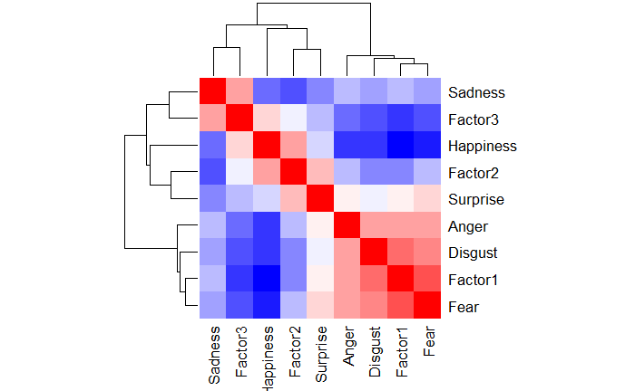

```r
col<-colorRampPalette(c("blue", "white","red"))(20)
heatmap(x=corfac2, col=col,symm=TRUE)
```

```r
corrplot(corfac2, type="upper",  tl.col="black", tl.srt = 45)
```

[output not shown]

# Step 4: Hierarchichal Linear Models for all 3 Factors

## Subjective Ratings Factor 1

HLM Factor 1

```
boundary (singular) fit: see ?isSingular
```

Anova Factor 1

[output not shown]

Confidence Intervals Factor 1

[output not shown]

Df to plot Factor 1

HLM Factor 2

```
Linear mixed model fit by maximum likelihood . t-tests use
  Satterthwaite's method [lmerModLmerTest]
Formula: ZCFA_F2 ~ 1 + (1 | ID)
   Data: ZnewFA_data

     AIC      BIC   logLik deviance df.resid
  1884.8   1898.4   -939.4   1878.8      700

Scaled residuals:
    Min      1Q  Median      3Q     Max
-2.2071 -0.7267 -0.1528  0.6854  2.9939

Random effects:
 Groups   Name        Variance Std.Dev.
 ID       (Intercept) 0.2463   0.4963
 Residual             0.7528   0.8676
Number of obs: 703, groups:  ID, 47

Fixed effects:
             Estimate Std. Error        df t value Pr(>|t|)
(Intercept)  0.001722   0.079442 46.957825   0.022    0.983
$Models

Model: "lmer, ZCFA_F2 ~ Z_Neutral_FaceMeanDIV + Z_Happy_FaceMeanDIV + Z_Sadness_FaceMeanDIV + Z_Surprise_FaceMeanDIV + Z_Fear_FaceMeanDIV + Z_meangsrB + Z_meanSUM_N_IncAB + (1 | ID), ZnewFA_data, FALSE"
Null:  "lmer, ZCFA_F2 ~ 1 + (1 | ID), ZnewFA_data, FALSE"

$Pseudo.R.squared.for.model.vs.null
                             Pseudo.R.squared
McFadden                            0.0199582
Cox and Snell (ML)                  0.0519403
Nagelkerke (Cragg and Uhler)        0.0557947

$Likelihood.ratio.test
 Df.diff LogLik.diff  Chisq    p.value
      -7     -18.748 37.497 3.7766e-06

$Number.of.observations

Model: 703
Null:  703

$Messages
[1] "Note: For models fit with REML, these statistics are based on refitting with ML"

$Warnings
[1] "None"
```

Anova Factor 2

```
Type III Analysis of Variance Table with Satterthwaite's method
                       Sum Sq Mean Sq NumDF  DenDF F value   Pr(>F)
Z_Neutral_FaceMeanDIV  7.0822  7.0822     1 657.43  9.9467 0.001685 **
Z_Happy_FaceMeanDIV    3.7607  3.7607     1 657.08  5.2818 0.021863 *
Z_Sadness_FaceMeanDIV  4.2632  4.2632     1 656.45  5.9875 0.014669 *
Z_Surprise_FaceMeanDIV 0.6826  0.6826     1 656.75  0.9588 0.327862
Z_Fear_FaceMeanDIV     0.9006  0.9006     1 663.96  1.2648 0.261147
Z_meangsrB             2.4048  2.4048     1 107.68  3.3775 0.068849 .
Z_meanSUM_N_IncAB      5.1977  5.1977     1 702.89  7.3000 0.007062 **
---
Signif. codes:  0 ‘***’ 0.001 ‘**’ 0.01 ‘*’ 0.05 ‘.’ 0.1 ‘ ’ 1
```

Model Summary Factor 2

```
Linear mixed model fit by maximum likelihood . t-tests use
  Satterthwaite's method [lmerModLmerTest]
Formula:
ZCFA_F2 ~ Z_Neutral_FaceMeanDIV + Z_Happy_FaceMeanDIV + Z_Sadness_FaceMeanDIV +
    Z_Surprise_FaceMeanDIV + Z_Fear_FaceMeanDIV + Z_meangsrB +
    Z_meanSUM_N_IncAB + (1 | ID)
   Data: ZnewFA_data

     AIC      BIC   logLik deviance df.resid
  1861.3   1906.8   -920.6   1841.3      693

Scaled residuals:
    Min      1Q  Median      3Q     Max
-2.3463 -0.7112 -0.1281  0.6300  3.0063

Random effects:
 Groups   Name        Variance Std.Dev.
 ID       (Intercept) 0.2429   0.4929
 Residual             0.7120   0.8438
Number of obs: 703, groups:  ID, 47

Fixed effects:
                         Estimate Std. Error         df t value Pr(>|t|)
(Intercept)              0.001364   0.078627  46.887415   0.017  0.98623
Z_Neutral_FaceMeanDIV    0.103057   0.032677 657.432597   3.154  0.00168
Z_Happy_FaceMeanDIV      0.076866   0.033446 657.082650   2.298  0.02186
Z_Sadness_FaceMeanDIV   -0.079663   0.032556 656.452105  -2.447  0.01467
Z_Surprise_FaceMeanDIV  -0.033020   0.033723 656.746816  -0.979  0.32786
Z_Fear_FaceMeanDIV       0.038141   0.033914 663.960863   1.125  0.26115
Z_meangsrB               0.121985   0.066376 107.682526   1.838  0.06885
Z_meanSUM_N_IncAB        0.099626   0.036873 702.888995   2.702  0.00706

(Intercept)
Z_Neutral_FaceMeanDIV  **
Z_Happy_FaceMeanDIV    *
Z_Sadness_FaceMeanDIV  *
Z_Surprise_FaceMeanDIV
Z_Fear_FaceMeanDIV
Z_meangsrB             .
Z_meanSUM_N_IncAB      **
---
Signif. codes:  0 ‘***’ 0.001 ‘**’ 0.01 ‘*’ 0.05 ‘.’ 0.1 ‘ ’ 1

Correlation of Fixed Effects:
            (Intr) Z_N_FM Z_H_FM Z_Sd_FMDIV Z_Sr_FMDIV Z_F_FM Z_mngB
Z_Ntr_FMDIV  0.000
Z_Hpp_FMDIV  0.000  0.138
Z_Sdn_FMDIV  0.000  0.145  0.151
Z_Srp_FMDIV  0.000 -0.127 -0.156 -0.025
Z_Fr_FcMDIV -0.001  0.015 -0.141  0.010     -0.238
Z_meangsrB  -0.002  0.020 -0.006  0.010      0.019     -0.034
Z_SUM_N_IAB  0.000 -0.015 -0.056  0.034      0.060     -0.012  0.011
```

Confidence Intervals Factor 2

```
                              2.5 %      97.5 %
.sig01                           NA          NA
.sigma                           NA          NA
(Intercept)            -0.152741856  0.15546952
Z_Neutral_FaceMeanDIV   0.039012014  0.16710225
Z_Happy_FaceMeanDIV     0.011312988  0.14241913
Z_Sadness_FaceMeanDIV  -0.143471898 -0.01585376
Z_Surprise_FaceMeanDIV -0.099114734  0.03307528
Z_Fear_FaceMeanDIV     -0.028329284  0.10461219
Z_meangsrB             -0.008108815  0.25207977
Z_meanSUM_N_IncAB       0.027355774  0.17189620
```

Df to plot Factor 2

Plot Factor 2

[figure not shown]

HLM Factor 3

```
Linear mixed model fit by maximum likelihood . t-tests use
  Satterthwaite's method [lmerModLmerTest]
Formula: ZCFA_F3 ~ 1 + (1 | ID)
   Data: ZnewFA_data

     AIC      BIC   logLik deviance df.resid
  1901.7   1915.4   -947.9   1895.7      700

Scaled residuals:
    Min      1Q  Median      3Q     Max
-1.8337 -0.8014 -0.2314  0.6670  3.4915

Random effects:
 Groups   Name        Variance Std.Dev.
 ID       (Intercept) 0.2212   0.4703
 Residual             0.7771   0.8815
Number of obs: 703, groups:  ID, 47

Fixed effects:
             Estimate Std. Error        df t value Pr(>|t|)
(Intercept) 6.803e-04  7.623e-02 4.704e+01   0.009    0.993
$Models

Model: "lmer, ZCFA_F3 ~ Z_Neutral_FaceMeanDIV + Z_Sadness_FaceMeanDIV + Z_Anger_FaceMeanDIV + Z_meanAccelB + Z_meangsrB + Z_meanSUM_N_IncAB + Z_meanbvpAmpB + (1 | ID), ZnewFA_data, FALSE"
Null:  "lmer, ZCFA_F3 ~ 1 + (1 | ID), ZnewFA_data, FALSE"

$Pseudo.R.squared.for.model.vs.null
                             Pseudo.R.squared
McFadden                            0.0204266
Cox and Snell (ML)                  0.0535932
Nagelkerke (Cragg and Uhler)        0.0574685

$Likelihood.ratio.test
 Df.diff LogLik.diff  Chisq   p.value
      -7     -19.362 38.723 2.207e-06

$Number.of.observations

Model: 703
Null:  703

$Messages
[1] "Note: For models fit with REML, these statistics are based on refitting with ML"

$Warnings
[1] "None"
```

Anova Factor 3

```
Type III Analysis of Variance Table with Satterthwaite's method
                       Sum Sq Mean Sq NumDF  DenDF F value    Pr(>F)
Z_Neutral_FaceMeanDIV  0.7777  0.7777     1 655.96  1.0688  0.301602
Z_Sadness_FaceMeanDIV  6.1703  6.1703     1 654.90  8.4802  0.003713 **
Z_Anger_FaceMeanDIV    4.7071  4.7071     1 656.90  6.4692  0.011204 *
Z_meanAccelB          11.8083 11.8083     1 688.16 16.2287 6.239e-05 ***
Z_meangsrB             4.4129  4.4129     1 111.23  6.0649  0.015323 *
Z_meanSUM_N_IncAB      1.1255  1.1255     1 702.81  1.5468  0.214025
Z_meanbvpAmpB          0.9604  0.9604     1 247.74  1.3200  0.251704
---
Signif. codes:  0 ‘***’ 0.001 ‘**’ 0.01 ‘*’ 0.05 ‘.’ 0.1 ‘ ’ 1
```

Model Summary Factor 3

```
Linear mixed model fit by maximum likelihood . t-tests use
  Satterthwaite's method [lmerModLmerTest]
Formula:
ZCFA_F3 ~ Z_Neutral_FaceMeanDIV + Z_Sadness_FaceMeanDIV + Z_Anger_FaceMeanDIV +
    Z_meanAccelB + Z_meangsrB + Z_meanSUM_N_IncAB + Z_meanbvpAmpB +
    (1 | ID)
   Data: ZnewFA_data

     AIC      BIC   logLik deviance df.resid
  1877.0   1922.6   -928.5   1857.0      693

Scaled residuals:
    Min      1Q  Median      3Q     Max
-1.8617 -0.7401 -0.1693  0.6664  3.3838

Random effects:
 Groups   Name        Variance Std.Dev.
 ID       (Intercept) 0.2515   0.5015
 Residual             0.7276   0.8530
Number of obs: 703, groups:  ID, 47

Fixed effects:
                        Estimate Std. Error         df t value Pr(>|t|)
(Intercept)            2.922e-04  7.991e-02  4.449e+01   0.004  0.99710
Z_Neutral_FaceMeanDIV  3.394e-02  3.283e-02  6.560e+02   1.034  0.30160
Z_Sadness_FaceMeanDIV  9.626e-02  3.306e-02  6.549e+02   2.912  0.00371
Z_Anger_FaceMeanDIV   -8.430e-02  3.314e-02  6.569e+02  -2.543  0.01120
Z_meanAccelB          -1.668e-01  4.141e-02  6.882e+02  -4.028 6.24e-05
Z_meangsrB             1.692e-01  6.871e-02  1.112e+02   2.463  0.01532
Z_meanSUM_N_IncAB      4.635e-02  3.727e-02  7.028e+02   1.244  0.21402
Z_meanbvpAmpB         -6.599e-02  5.744e-02  2.477e+02  -1.149  0.25170

(Intercept)
Z_Neutral_FaceMeanDIV
Z_Sadness_FaceMeanDIV **
Z_Anger_FaceMeanDIV   *
Z_meanAccelB          ***
Z_meangsrB            *
Z_meanSUM_N_IncAB
Z_meanbvpAmpB
---
Signif. codes:  0 ‘***’ 0.001 ‘**’ 0.01 ‘*’ 0.05 ‘.’ 0.1 ‘ ’ 1

Correlation of Fixed Effects:
            (Intr) Z_N_FM Z_S_FM Z_A_FM Z_mnAcB Z_mngB Z_SUM_
Z_Ntr_FMDIV  0.000
Z_Sdn_FMDIV  0.000  0.146
Z_Ang_FMDIV  0.000  0.128  0.174
Z_meanAcclB  0.000  0.008  0.065  0.104
Z_meangsrB  -0.002  0.018  0.007  0.004 -0.139
Z_SUM_N_IAB  0.000 -0.009  0.036 -0.053  0.041   0.002
Z_mnbvpAmpB  0.000  0.037 -0.012 -0.044  0.000  -0.146  0.000
```

Confidence Intervals Factor 3

```
                            2.5 %      97.5 %
.sig01                         NA          NA
.sigma                         NA          NA
(Intercept)           -0.15633357  0.15691795
Z_Neutral_FaceMeanDIV -0.03040159  0.09827363
Z_Sadness_FaceMeanDIV  0.03147207  0.16104524
Z_Anger_FaceMeanDIV   -0.14926326 -0.01933946
Z_meanAccelB          -0.24798666 -0.08565935
Z_meangsrB             0.03454260  0.30387323
Z_meanSUM_N_IncAB     -0.02669609  0.11940467
Z_meanbvpAmpB         -0.17857312  0.04658731
```

Df to plot Factor 3

plot Factor 3

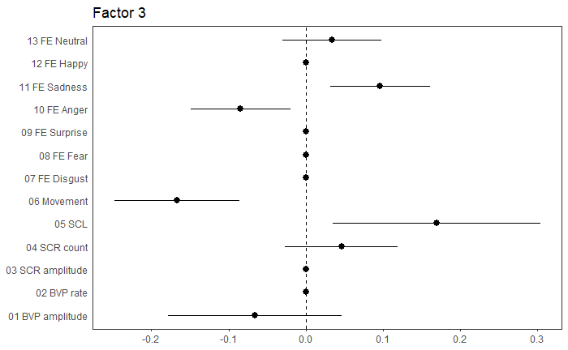

combine all plots

[figure not shown]